# Human Activity Recognition Using Machine Learning

Kanthimathi Gayatri Sukumar

Friday, February 11, 2015

# I. Introduction

Human Activity Recognition - HAR - has emerged as a key research area in the last few years and is gaining increasing attention.

This particular data analysis attempts to accurately predict a particular human activity (Unilateral Dumbbell Biceps Curl) using the data from from a human activity research at http://groupware.les.inf.puc-rio.br/har (Please see this webpage for detailed information). This dataset is licensed under the Creative Commons license (CC BY-SA). The research has been conducted by observing six young adults perfom these activities while recording the data from thier arm, belt, forearm and dumbbell sensors.

**Goal / Prediction / Dependent Variable: THE ACTIVITY PERFORMED.** Unilateral Dumbbell Biceps Curl in five different types (ways): exactly according to the specification (Class A), throwing the elbows to the front (Class B), lifting the dumbbell only halfway (Class C), lowering the dumbbell only halfway (Class D) and throwing the hips to the front (Class E).

**Predictors / Independent Variables: SENSOR INFORMATION.** Arm sensor orientation variables, Belt sensor orientation variables, Forearm sensor orientation variables and Dumbbell sensor orientation variables (all on the X, Y and Z axes)

# II. Executive Summary

The Unilateral Dumbbell Biceps Curl activity type (as classified by A, B, C,D and E) is predicted using **Random Forest modelling with 10 fold cross validation**. The prediction model has an **Out of Sample Error rate of 0.365%**. A low Out of Sample Error rate also signifies that the over-fitting has not occurred.

The model has been selected after cleaning, exploring and applying various models of CART, Boosting, Random Forest and Linear Discriminant Analysis and comparing thier results.

The Random Forest model accuracy is limited to the *six young adults* who participated in the research. Application outside of this limitation will not be reliable.

There is also futher scope to use Kappa and ROC for model comparison and selection (possibly between Boosting and Randon Forest for this data set).

# III. Data Analysis

## 1. Getting the Data

The data for analysis is downloaded from http://d396qusza40orc.cloudfront.net/predmachlearn. The below code downloads the file, saves it and then reads the data into R.

The training.csv file is used for the predictive modelling through outin this analysis.

The selected prediction model is then applied on the testing.csv file and the result uploaded in Coursera Machine Learning Class project.

```r
setwd ("C:/Users/KanthimathiGayatri/Desktop/ML")

trainingFile = "./pml-training.csv"
if (!file.exists (trainingFile))
    download.file ("http://d396qusza40orc.cloudfront.net/predmachlearn/pml-training.csv", trainingFile)
training = read.csv (trainingFile)

testingFile = "./pml-testing.csv"
if (!file.exists (testingFile))
    download.file ("http://d396qusza40orc.cloudfront.net/predmachlearn/pml-testing.csv", testingFile)
testing = read.csv (testingFile)

#Size of training data
dim (training)
```

```
## [1] 19622   160
```

```r
#Size of testing data
dim (testing)
```

```
## [1]  20 160
```

## 2. Splitting the data into train and test samples

We will split the *training.csv* data into our own training and test sample sets in the proportion of 70:30 over the prediction variable *classe* (denotes the activity type).

We will also set the pseudo random number for the purpose of reproducibility.

```r
set.seed (12345)
inTrain = createDataPartition (y = training$classe, p = 0.7, list = FALSE)
myTrain = training [inTrain, ]
myTest = training [-inTrain, ]
dim(myTrain); dim(myTest)
```

```
## [1] 13737   160
```

```
## [1] 5885  160
```

Dataset **myTrain** represents the train data and **myTest** the test data. With this, we will set **myTest** aside until models are ready to be tested.

## 3. Cleaning the Data

**[At several places during cleaning, the results are hidden due to the verbosity. However, the summary of the data before and after the cleaning are added to the appendix for reference]**

Let us print the summary of the data to understand it better.

```r
summary(myTrain)
#Hiding the results due to verbosity...
```

```r
head (myTrain, 50)
#Hiding the results due to verbosity...
```

```r
myCleanTrain = subset (myTrain, new_window == "no")

naVecs = colSums (is.na (myCleanTrain)) < nrow (myCleanTrain)
myCleanTrain = myCleanTrain [ , naVecs]
```

Next, let us look for near zero variance variables that will not be of use for modelling and remove these.

```r
nzv = nearZeroVar (myCleanTrain) #saveMetrics was TRUE during exploration.
myCleanTrain = subset (myCleanTrain, select = -(nzv))
```

We will also remove the variables that are not relavant for the prediction of the activity type, the *classe* variable.

```r
# Remove variables X, user_name, raw_timestamp_part_1, raw_timestamp_part_2 and cvtd_timestamp. Not relavant to predict classe.
myCleanTrain = subset (myCleanTrain, select = -(X:cvtd_timestamp))
```

Let us now check the final cleaned variable names -

```r
names(myCleanTrain)
```

```
##  [1] "num_window"           "roll_belt"            "pitch_belt"
##  [4] "yaw_belt"             "total_accel_belt"     "gyros_belt_x"
##  [7] "gyros_belt_y"         "gyros_belt_z"         "accel_belt_x"
## [10] "accel_belt_y"         "accel_belt_z"         "magnet_belt_x"
## [13] "magnet_belt_y"        "magnet_belt_z"        "roll_arm"
## [16] "pitch_arm"            "yaw_arm"              "total_accel_arm"
## [19] "gyros_arm_x"          "gyros_arm_y"          "gyros_arm_z"
## [22] "accel_arm_x"          "accel_arm_y"          "accel_arm_z"
## [25] "magnet_arm_x"         "magnet_arm_y"         "magnet_arm_z"
## [28] "roll_dumbbell"        "pitch_dumbbell"       "yaw_dumbbell"
## [31] "total_accel_dumbbell" "gyros_dumbbell_x"     "gyros_dumbbell_y"
## [34] "gyros_dumbbell_z"     "accel_dumbbell_x"     "accel_dumbbell_y"
## [37] "accel_dumbbell_z"     "magnet_dumbbell_x"    "magnet_dumbbell_y"
## [40] "magnet_dumbbell_z"    "roll_forearm"         "pitch_forearm"
## [43] "yaw_forearm"          "total_accel_forearm"  "gyros_forearm_x"
## [46] "gyros_forearm_y"      "gyros_forearm_z"      "accel_forearm_x"
## [49] "accel_forearm_y"      "accel_forearm_z"      "magnet_forearm_x"
## [52] "magnet_forearm_y"     "magnet_forearm_z"     "classe"
```

```r
nVars = ncol(myCleanTrain)
```

## 4.Machine Learning / Prediction Modelling

**[Refer to the Appendix for Data Exploration Activities and Findings]**

In order to predict activity, as indicated by the categorical variable *classe* (factors “A”, “B”, “C”, “D”, “E”), we have created several models and chosen the best that gives the highest Accuracy.

The models that have been used are Classification and Regression Tree (CART), Linear Discriminant Analysis (LDA), Boosting and Random Forest. The predictions also use cross-validation to improve the modelling. We will also be performing transformations before modelling the parametric LDA.

With each model, the IN SAMPLE ERROR (Resubstitution Error) using *myCleanTrain* data set and OUT OF SAMPLE ERROR (Generalization Error) using a cleaned *myTest* and calculated and used for finding the best model fit.

The errors have been the least for **Random Forest** prediction for this dataset.

We will describe the prediction and accuracy using Random Forest below.

**[Refer to the Appendix for prediction and accuracy using CART, LDA and Boosting]**

A 10-fold cross validation has been used to reduce over-fitting duing Random Forest modelling. The splitting of the data set in to a 70:30 training:test is also to detect over-fitting.

Before modelling, let us apply the same cleaning method that we created with *myTrain* dataset, on the *myTest* dataset. The cleaned myTest dataset is needed for the OUT OF SAMPLE ERROR computation.

```r
myCleanTest = subset (myTest, new_window == "no")
myCleanTest = myCleanTest [ , naVecs]
myCleanTest = subset (myCleanTest, select = -(nzv))
myCleanTest = subset (myCleanTest, select = -(X:cvtd_timestamp))
```

**RANDOM FOREST MODELLING**

Random Forest is performed on the cleaned training data, with a cross-validation of 10 folds.

```r
fitControl = trainControl (method = "cv", number = 10)
rfFit = train (classe ~ ., data = myCleanTrain, method = "rf", trControl = fitControl, verbose = FALSE)

# Print the Fit
rfFit
```

```
## Random Forest
##
## 13464 samples
##    53 predictor
##     5 classes: 'A', 'B', 'C', 'D', 'E'
##
## No pre-processing
## Resampling: Cross-Validated (10 fold)
##
## Summary of sample sizes: 12118, 12118, 12119, 12116, 12118, 12117, ...
##
## Resampling results across tuning parameters:
##
##   mtry  Accuracy   Kappa      Accuracy SD  Kappa SD
##    2    0.9945775  0.9931403  0.002952517  0.003735445
##   27    0.9973999  0.9967110  0.001724968  0.002182230
##   53    0.9947256  0.9933273  0.003630689  0.004594744
##
## Accuracy was used to select the optimal model using  the largest value.
## The final value used for the model was mtry = 27.
```

```r
# Print the model
rfFit$finalModel
```

```
##
## Call:
##  randomForest(x = x, y = y, mtry = param$mtry, verbose = FALSE)
##                Type of random forest: classification
##                      Number of trees: 500
## No. of variables tried at each split: 27
##
##         OOB estimate of  error rate: 0.19%
## Confusion matrix:
##      A    B    C    D    E  class.error
## A 3828    1    0    0    1 0.0005221932
## B    6 2592    2    1    0 0.0034602076
## C    0    3 2341    1    0 0.0017057569
## D    0    0    6 2206    0 0.0027124774
## E    0    0    0    4 2472 0.0016155089
```

```r
# Print Accuracy IN SAMPLE
accuracyIS = confusionMatrix (myCleanTrain$classe, predict (rfFit, myCleanTrain))$overall[1]
accuracyIS
```

```
## Accuracy
##        1
```

```r
# Print Accuracy OUT OF SAMPLE
accuracyOS = confusionMatrix (myCleanTest$classe, predict (rfFit, myCleanTest))$overall[1]
accuracyOS
```

```
##  Accuracy
## 0.9963491
```

The Random Forest model yields an **in-sample error of 0%** and an **out-of-sample error of 0.365%**.

# IV. Prediction on Original Test Data (Conclusion)

Finally, let us apply the random forest model to predict the human activity for the project’s original test data **testing** from *testing.csv*

We will once again apply the same cleaning method to this data.

```r
myValidationTest = subset (testing, new_window == "no")
myValidationTest = myValidationTest [ , naVecs]
myValidationTest = subset (myValidationTest, select = -(nzv))
myValidationTest = subset (myValidationTest, select = -(X:cvtd_timestamp))
```

```r
pred = predict (rfFit, myValidationTest)
pred
```

```
##  [1] B A B A A E D B A A B C B A E E A B B B
## Levels: A B C D E
```

The predictions for the **Testing** data using random forest modelling are **B, A, B, A, A, E, D, B, A, A, B, C, B, A, E, E, A, B, B, B**

# Appendix

## A. Data Exploration

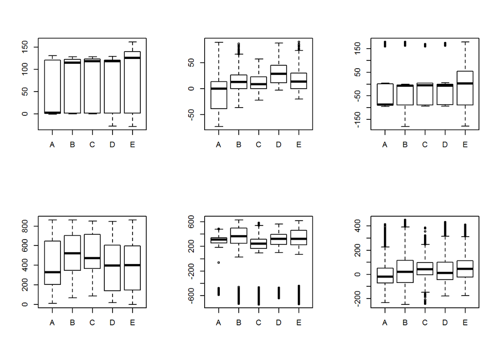

```r
par (mfrow = c(2,3))

boxplot (roll_belt ~ classe, data = myCleanTrain)
boxplot (pitch_forearm ~ classe, data = myCleanTrain)
boxplot (yaw_belt ~ classe, data = myCleanTrain)
boxplot (num_window ~ classe, data = myCleanTrain)
boxplot (magnet_dumbbell_y ~ classe, data = myCleanTrain)
boxplot (magnet_dumbbell_z ~ classe, data = myCleanTrain)
```

```r
par (mfrow = c(1,1))

summary (myCleanTrain[,c("roll_belt", "pitch_forearm", "yaw_belt")])
```

```
##    roll_belt       pitch_forearm        yaw_belt
##  Min.   :-28.900   Min.   :-72.500   Min.   :-180.00
##  1st Qu.:  1.097   1st Qu.:  0.000   1st Qu.: -88.30
##  Median :113.000   Median :  9.595   Median : -13.10
##  Mean   : 64.360   Mean   : 10.955   Mean   : -10.97
##  3rd Qu.:123.000   3rd Qu.: 28.600   3rd Qu.:  13.43
##  Max.   :162.000   Max.   : 89.800   Max.   : 179.00
```

```r
summary (myCleanTrain[,c("num_window", "magnet_dumbbell_y", "magnet_dumbbell_z")])
```

```
##    num_window    magnet_dumbbell_y magnet_dumbbell_z
##  Min.   :  1.0   Min.   :-744      Min.   :-250.00
##  1st Qu.:220.8   1st Qu.: 231      1st Qu.: -46.00
##  Median :424.0   Median : 310      Median :  13.00
##  Mean   :430.1   Mean   : 219      Mean   :  45.84
##  3rd Qu.:643.0   3rd Qu.: 390      3rd Qu.:  94.25
##  Max.   :864.0   Max.   : 632      Max.   : 452.00
```

From the above exploration, we can observe the below about the variables -

**roll_belt** - Appears very clean and usable in modelling.

**pitch_forearm** - Appears clean with few outliers for activity B.

**yaw_belt** - Appears to have outliers in positive direction… Would be a good idea to apply log10 on this variable for parametric modelling. Outliers should not pose a problem for non-parametric modelling.

**num_window** - Appears very clean and usable in modelling.

**magnet_dumbbell_z** - Appears to have heavy outliers and a high spread. Definitely needs to be transformed using log10 for parametric modelling.

We will also check if any of the variables are correlated.

```r
#Perform correlation without the prediction variable
indexClasse = which (colnames (myCleanTrain) == "classe")

corMat = abs(round (cor(myCleanTrain[,-indexClasse]), 2))
diag (corMat) = 0
which (corMat > 0.8, arr.ind = TRUE) #print high correlation indices
```

```
##                  row col
## yaw_belt           4   2
## total_accel_belt   5   2
## accel_belt_y      10   2
## accel_belt_z      11   2
## accel_belt_x       9   3
## magnet_belt_x     12   3
## roll_belt          2   4
## roll_belt          2   5
## accel_belt_y      10   5
## accel_belt_z      11   5
## pitch_belt         3   9
## magnet_belt_x     12   9
## roll_belt          2  10
## total_accel_belt   5  10
## accel_belt_z      11  10
## roll_belt          2  11
## total_accel_belt   5  11
## accel_belt_y      10  11
## pitch_belt         3  12
## accel_belt_x       9  12
## gyros_arm_y       20  19
## gyros_arm_x       19  20
## magnet_arm_x      25  22
## accel_arm_x       22  25
## magnet_arm_z      27  26
## magnet_arm_y      26  27
## accel_dumbbell_x  35  29
## accel_dumbbell_z  37  30
## gyros_dumbbell_z  34  32
## gyros_forearm_z   47  32
## gyros_dumbbell_x  32  34
## gyros_forearm_z   47  34
## pitch_dumbbell    29  35
## yaw_dumbbell      30  37
## gyros_forearm_z   47  46
## gyros_dumbbell_x  32  47
## gyros_dumbbell_z  34  47
## gyros_forearm_y   46  47
```

There does appear to be predictor variables that are correlated. Principal Component Analysis would be required to be performed for parametric modelling.

## B. Other Models Explored with their Prediction Accuracy

### 1. Classification and Regression Tree (CART)

CART is performed on the cleaned training data, with a cross-validation of 10 folds. There was no change in the result when the cross-validation folds were increased to 20.

```r
fitControl = trainControl (method = "cv", number = 10)
cartFit = train (classe ~ ., method = "rpart", data = myCleanTrain, trControl = fitControl)

# Print Model
cartFit$finalModel
```

```
## n= 13464
##
## node), split, n, loss, yval, (yprob)
##       * denotes terminal node
##
##  1) root 13464 9634 A (0.28 0.19 0.17 0.16 0.18)
##    2) roll_belt< 129.5 12272 8482 A (0.31 0.21 0.19 0.18 0.11)
##      4) pitch_forearm< -33.95 1072    9 A (0.99 0.0084 0 0 0) *
##      5) pitch_forearm>=-33.95 11200 8473 A (0.24 0.23 0.21 0.2 0.12)
##       10) num_window>=45.5 10689 7962 A (0.26 0.24 0.22 0.2 0.086)
##         20) magnet_dumbbell_y< 439.5 9123 6455 A (0.29 0.19 0.25 0.19 0.083)
##           40) roll_forearm< 123.5 5746 3350 A (0.42 0.19 0.19 0.16 0.042) *
##           41) roll_forearm>=123.5 3377 2202 C (0.081 0.19 0.35 0.23 0.15) *
##         21) magnet_dumbbell_y>=439.5 1566  679 B (0.038 0.57 0.05 0.24 0.1) *
##       11) num_window< 45.5 511  106 E (0 0 0 0.21 0.79) *
##    3) roll_belt>=129.5 1192   40 E (0.034 0 0 0 0.97) *
```

```r
# Print Accuracy IN SAMPLE
accuracyIS = confusionMatrix (myCleanTrain$classe, predict (cartFit, myCleanTrain))$overall[1]
accuracyIS
```

```
##  Accuracy
## 0.5256982
```

```r
# Print Accuracy OUT OF SAMPLE
accuracyOS = confusionMatrix (myCleanTest$classe, predict (cartFit, myCleanTest))$overall[1]
accuracyOS
```

```
##  Accuracy
## 0.5239917
```

The CART model yields an **in-sample error of 47.4%** and an **out-of-sample error of 47.6%**.

### 2. BOOSTING

Boosting is performed on the cleaned training data, with a cross-validation of 10 folds.

```r
fitControl = trainControl (method = "cv", number = 10)
boostFit = train (classe ~ ., data = myCleanTrain, method = "gbm", trControl = fitControl, verbose = FALSE)

# Print Accuracy IN SAMPLE
accuracyIS = confusionMatrix (myCleanTrain$classe, predict (boostFit, myCleanTrain))$overall[1]
accuracyIS
```

```
##  Accuracy
## 0.9942068
```

```r
# Print Accuracy OUT OF SAMPLE
accuracyOS = confusionMatrix (myCleanTest$classe, predict (boostFit, myCleanTest))$overall[1]
accuracyOS
```

```
##  Accuracy
## 0.9874826
```

The BOOSTING model yields an **in-sample error of 0.579%** and an **out-of-sample error of 1.25%**.

Although the out-of-sample error rate is very low, it is slightly more lower for Random Forest model.

### 3. Linear Discriminant Analysis (LDA)

There was no change in the result when the cross-validation folds were increased to 20. Selecting the variables based on variable importance from the other non-parametric models and applying a logrithmic transformation to the very high spread variables (based on data exploration) also did not improve the prediction accuracy.

```r
###Linear Discriminant Analysis
fitControl = trainControl (method = "cv", number = 10)
ldaFit = train (classe ~ ., method = "lda", preprocess = c("center", "scale", "pca"), data = myCleanTrain, trControl = fitControl) #pca will also include scaling

# Print Accuracy IN SAMPLE
accuracyIS = ldaFit$results$Accuracy
accuracyIS
```

```
## [1] 0.7147225
```

```r
# Print Accuracy OUT OF SAMPLE
accuracyOS = confusionMatrix (myCleanTest$classe, predict (ldaFit, myCleanTest))$overall[1]
accuracyOS
```

```
## Accuracy
## 0.706363
```

The LDA model yields an **in-sample error of 28.5%** and an **out-of-sample error of 29.4%**.

## C. Data Summary Before and After Cleaning

Below is the summary of the data **before cleaning**.

```r
summary (myTrain)
```

```
##        X            user_name    raw_timestamp_part_1 raw_timestamp_part_2
##  Min.   :    2   adelmo  :2749   Min.   :1.322e+09    Min.   :   294
##  1st Qu.: 4909   carlitos:2199   1st Qu.:1.323e+09    1st Qu.:254958
##  Median : 9811   charles :2418   Median :1.323e+09    Median :500340
##  Mean   : 9810   eurico  :2122   Mean   :1.323e+09    Mean   :502510
##  3rd Qu.:14679   jeremy  :2386   3rd Qu.:1.323e+09    3rd Qu.:752385
##  Max.   :19622   pedro   :1863   Max.   :1.323e+09    Max.   :998801
##
##           cvtd_timestamp new_window    num_window      roll_belt
##  28/11/2011 14:14:1033   no :13464   Min.   :  1.0   Min.   :-28.90
##  05/12/2011 11:24:1028   yes:  273   1st Qu.:220.0   1st Qu.:  1.10
##  05/12/2011 11:25:1026               Median :424.0   Median :113.00
##  30/11/2011 17:11:1014               Mean   :430.1   Mean   : 64.44
##  02/12/2011 13:34: 985               3rd Qu.:643.0   3rd Qu.:123.00
##  05/12/2011 14:23: 965               Max.   :864.0   Max.   :162.00
##  (Other)         :7686
##    pitch_belt         yaw_belt       total_accel_belt kurtosis_roll_belt
##  Min.   :-54.700   Min.   :-180.00   Min.   : 0.00             :13464
##  1st Qu.:  1.690   1st Qu.: -88.30   1st Qu.: 3.00    #DIV/0!  :    7
##  Median :  5.280   Median : -13.00   Median :17.00    -1.908453:    2
##  Mean   :  0.231   Mean   : -10.91   Mean   :11.32    -0.025513:    1
##  3rd Qu.: 14.800   3rd Qu.:  13.60   3rd Qu.:18.00    -0.033935:    1
##  Max.   : 60.200   Max.   : 179.00   Max.   :28.00    -0.034743:    1
##                                                       (Other)  :  261
##  kurtosis_picth_belt kurtosis_yaw_belt skewness_roll_belt
##           :13464            :13464              :13464
##  #DIV/0!  :   24     #DIV/0!:  273     #DIV/0!  :    7
##  -0.684748:    3                       0.000000 :    3
##  1.326417 :    3                       0.422463 :    2
##  11.094417:    3                       -0.003095:    1
##  -1.750749:    2                       -0.010002:    1
##  (Other)  :  238                       (Other)  :  259
##  skewness_roll_belt.1 skewness_yaw_belt max_roll_belt     max_picth_belt
##           :13464             :13464     Min.   :-94.300   Min.   : 3.00
##  #DIV/0!  :   24      #DIV/0!:  273     1st Qu.:-88.100   1st Qu.: 5.00
##  -0.189082:    2                        Median : -4.900   Median :18.00
##  -0.475418:    2                        Mean   : -5.412   Mean   :12.85
##  -1.159179:    2                        3rd Qu.: 21.800   3rd Qu.:19.00
##  -1.810464:    2                        Max.   :180.000   Max.   :30.00
##  (Other)  :  241                        NA's   :13464     NA's   :13464
```

[output cut: 305 more lines]

```
##  Min.   :-498.00   Min.   :-632.0   Min.   :-410.00   Min.   :-1280.0
##  1st Qu.:-179.00   1st Qu.:  54.0   1st Qu.:-183.00   1st Qu.: -617.0
##  Median : -57.00   Median : 201.0   Median : -42.00   Median : -383.0
##  Mean   : -62.22   Mean   : 163.5   Mean   : -56.63   Mean   : -314.7
##  3rd Qu.:  75.00   3rd Qu.: 312.0   3rd Qu.:  25.00   3rd Qu.:  -77.0
##  Max.   : 389.00   Max.   : 923.0   Max.   : 287.00   Max.   :  672.0
##
##  magnet_forearm_y magnet_forearm_z classe
##  Min.   :-896.0   Min.   :-966.0   A:3906
##  1st Qu.:  -3.0   1st Qu.: 194.0   B:2658
##  Median : 587.0   Median : 511.0   C:2396
##  Mean   : 375.8   Mean   : 395.6   D:2252
##  3rd Qu.: 736.0   3rd Qu.: 652.0   E:2525
##  Max.   :1480.0   Max.   :1090.0
##
```

```r
head (myTrain, 10)
```

```
##     X user_name raw_timestamp_part_1 raw_timestamp_part_2   cvtd_timestamp
## 2   2  carlitos           1323084231               808298 05/12/2011 11:23
## 3   3  carlitos           1323084231               820366 05/12/2011 11:23
## 4   4  carlitos           1323084232               120339 05/12/2011 11:23
## 5   5  carlitos           1323084232               196328 05/12/2011 11:23
## 6   6  carlitos           1323084232               304277 05/12/2011 11:23
## 7   7  carlitos           1323084232               368296 05/12/2011 11:23
## 8   8  carlitos           1323084232               440390 05/12/2011 11:23
## 12 12  carlitos           1323084232               528316 05/12/2011 11:23
## 13 13  carlitos           1323084232               560359 05/12/2011 11:23
## 14 14  carlitos           1323084232               576390 05/12/2011 11:23
##    new_window num_window roll_belt pitch_belt yaw_belt total_accel_belt
## 2          no         11      1.41       8.07    -94.4                3
## 3          no         11      1.42       8.07    -94.4                3
## 4          no         12      1.48       8.05    -94.4                3
```

[output cut: 436 more lines]

Below is the summary of the data **after cleaning** which was used for training the model.

```r
summary (myCleanTrain)
```

```
##    num_window      roll_belt         pitch_belt          yaw_belt
##  Min.   :  1.0   Min.   :-28.900   Min.   :-54.7000   Min.   :-180.00
##  1st Qu.:220.8   1st Qu.:  1.097   1st Qu.:  1.7200   1st Qu.: -88.30
##  Median :424.0   Median :113.000   Median :  5.2800   Median : -13.10
##  Mean   :430.1   Mean   : 64.360   Mean   :  0.2414   Mean   : -10.97
##  3rd Qu.:643.0   3rd Qu.:123.000   3rd Qu.: 14.8000   3rd Qu.:  13.43
##  Max.   :864.0   Max.   :162.000   Max.   : 60.2000   Max.   : 179.00
##  total_accel_belt  gyros_belt_x        gyros_belt_y       gyros_belt_z
##  Min.   : 0.00    Min.   :-1.040000   Min.   :-0.51000   Min.   :-1.3500
##  1st Qu.: 3.00    1st Qu.:-0.050000   1st Qu.: 0.00000   1st Qu.:-0.2000
##  Median :17.00    Median : 0.030000   Median : 0.02000   Median :-0.1000
##  Mean   :11.31    Mean   :-0.007288   Mean   : 0.03946   Mean   :-0.1313
##  3rd Qu.:18.00    3rd Qu.: 0.110000   3rd Qu.: 0.11000   3rd Qu.:-0.0200
##  Max.   :28.00    Max.   : 2.220000   Max.   : 0.64000   Max.   : 1.6100
##   accel_belt_x       accel_belt_y     accel_belt_z     magnet_belt_x
##  Min.   :-120.000   Min.   :-69.00   Min.   :-269.00   Min.   :-48.00
##  1st Qu.: -21.000   1st Qu.:  3.00   1st Qu.:-162.00   1st Qu.:  9.00
##  Median : -15.000   Median : 35.00   Median :-152.00   Median : 34.00
##  Mean   :  -5.523   Mean   : 30.12   Mean   : -72.58   Mean   : 55.59
##  3rd Qu.:  -5.000   3rd Qu.: 61.00   3rd Qu.:  27.00   3rd Qu.: 60.00
##  Max.   :  85.000   Max.   :164.00   Max.   : 105.00   Max.   :479.00
##  magnet_belt_y   magnet_belt_z       roll_arm         pitch_arm
##  Min.   :359.0   Min.   :-623.0   Min.   :-180.00   Min.   :-88.800
##  1st Qu.:581.0   1st Qu.:-375.0   1st Qu.: -30.70   1st Qu.:-26.100
##  Median :601.0   Median :-319.5   Median :   0.00   Median :  0.000
##  Mean   :593.7   Mean   :-345.3   Mean   :  18.22   Mean   : -4.643
##  3rd Qu.:610.0   3rd Qu.:-306.0   3rd Qu.:  77.30   3rd Qu.: 11.325
##  Max.   :673.0   Max.   : 293.0   Max.   : 180.00   Max.   : 88.500
##     yaw_arm         total_accel_arm  gyros_arm_x        gyros_arm_y
##  Min.   :-180.000   Min.   : 1.00   Min.   :-6.37000   Min.   :-3.4000
##  1st Qu.: -42.825   1st Qu.:17.00   1st Qu.:-1.32250   1st Qu.:-0.8000
##  Median :   0.000   Median :27.00   Median : 0.08000   Median :-0.2600
##  Mean   :  -1.099   Mean   :25.57   Mean   : 0.04716   Mean   :-0.2587
##  3rd Qu.:  45.300   3rd Qu.:33.00   3rd Qu.: 1.59000   3rd Qu.: 0.1400
##  Max.   : 180.000   Max.   :66.00   Max.   : 4.87000   Max.   : 2.8400
##   gyros_arm_z      accel_arm_x       accel_arm_y       accel_arm_z
##  Min.   :-2.330   Min.   :-383.00   Min.   :-318.00   Min.   :-636.00
##  1st Qu.:-0.070   1st Qu.:-242.00   1st Qu.: -54.00   1st Qu.:-144.00
##  Median : 0.230   Median : -41.00   Median :  14.00   Median : -46.00
##  Mean   : 0.271   Mean   : -58.62   Mean   :  32.41   Mean   : -71.62
```

[output cut: 50 more lines]

```
##  Max.   :311.00000   Max.   :231.0000   Max.   : 389.00   Max.   : 923.0
##  accel_forearm_z  magnet_forearm_x  magnet_forearm_y  magnet_forearm_z
##  Min.   :-410.0   Min.   :-1280.0   Min.   :-896.00   Min.   :-966.0
##  1st Qu.:-183.0   1st Qu.: -617.0   1st Qu.:  -2.25   1st Qu.: 193.0
##  Median : -42.0   Median : -383.0   Median : 587.00   Median : 511.0
##  Mean   : -56.5   Mean   : -314.6   Mean   : 376.17   Mean   : 395.3
##  3rd Qu.:  25.0   3rd Qu.:  -77.0   3rd Qu.: 736.00   3rd Qu.: 652.0
##  Max.   : 287.0   Max.   :  672.0   Max.   :1480.00   Max.   :1090.0
##  classe
##  A:3830
##  B:2601
##  C:2345
##  D:2212
##  E:2476
##
```

```r
head (myCleanTrain, 10)
```

```
##    num_window roll_belt pitch_belt yaw_belt total_accel_belt gyros_belt_x
## 2          11      1.41       8.07    -94.4                3         0.02
## 3          11      1.42       8.07    -94.4                3         0.00
## 4          12      1.48       8.05    -94.4                3         0.02
## 5          12      1.48       8.07    -94.4                3         0.02
## 6          12      1.45       8.06    -94.4                3         0.02
## 7          12      1.42       8.09    -94.4                3         0.02
## 8          12      1.42       8.13    -94.4                3         0.02
## 12         12      1.43       8.18    -94.4                3         0.02
## 13         12      1.42       8.20    -94.4                3         0.02
## 14         12      1.42       8.21    -94.4                3         0.02
##    gyros_belt_y gyros_belt_z accel_belt_x accel_belt_y accel_belt_z
## 2          0.00        -0.02          -22            4           22
## 3          0.00        -0.02          -20            5           23
## 4          0.00        -0.03          -22            3           21
```

[output cut: 117 more lines]